# Reproducible Research: Peer Assessment 1

L. Somuray

11/21/2020

## Loading and preprocessing the data

```r
library(Hmisc)
library(dplyr)
activity <- read.csv("activity.csv")
```

## What is mean total number of steps taken per day?

1.Total steps per day

```r
StepsPerDay <- aggregate(activity$steps, list(activity$date), FUN=sum)
colnames(StepsPerDay) <- c("Date", "Steps")
head(StepsPerDay)
```

```
##         Date Steps
## 1 2012-10-01    NA
## 2 2012-10-02   126
## 3 2012-10-03 11352
## 4 2012-10-04 12116
## 5 2012-10-05 13294
## 6 2012-10-06 15420
```

2. Make a histogram of the total number of steps taken each day

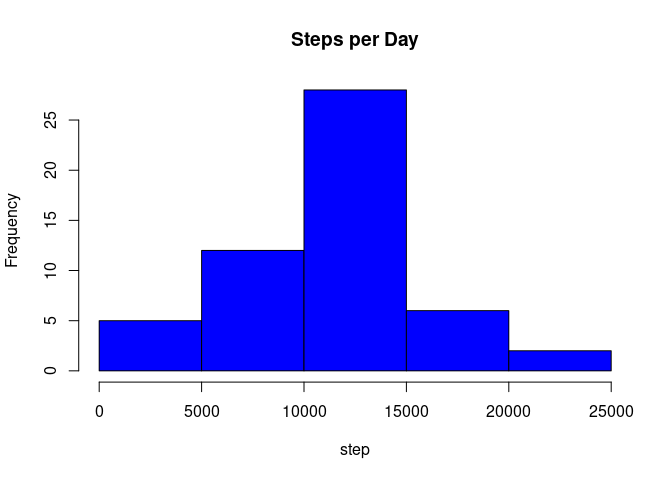

```r
hist(StepsPerDay[,2],main='Steps per Day' ,col='blue',xlab='step')
```

3.Calculate and report the **mean** and **median** total number of steps taken per day

```r
mean(StepsPerDay[,2],na.rm=TRUE)
```

```
## [1] 10766.19
```

```r
median(StepsPerDay[,2],na.rm=TRUE)
```

```
## [1] 10765
```

## What is the average daily activity pattern?

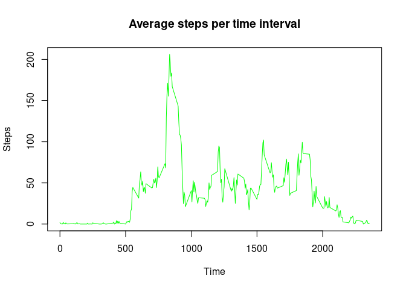

```r
StepsPerTime <- aggregate(steps~interval,data=activity,FUN=mean,na.action=na.omit)
plot(StepsPerTime,type='l',col='green',main="Average steps per time interval",xlab="Time" ,ylab="Steps")
```

Which 5-minute interval, on average across all the days in the dataset, contains the maximum number of steps?

```r
ST <- tbl_df(StepsPerTime)
ST %>% select(interval, steps) %>% filter(steps==max(ST$steps))
```

```
## # A tibble: 1 x 2
##   interval steps
##      <int> <dbl>
## 1      835  206.
```

## Imputing missing values,

1.Calculate and report the total number of missing values in the dataset (i.e. the total number of rows with `NA`s)

```r
length(which(is.na(activity$steps)))
```

```
## [1] 2304
```

2. Devise a strategy for filling in all of the missing values in the dataset. The strategy does not need to be sophisticated. For example, you could use the mean/median for that day, or the mean for that 5-minute interval, etc.

```r
activityImp <- activity
activityImp$steps <- impute(activity$steps, fun=mean)
```

3. Create a new dataset that is equal to the original dataset but with the missing data filled in.

```r
imputed_dataset <- activityImp
head(imputed_dataset)
```

```
##     steps       date interval
## 1 37.3826 2012-10-01        0
## 2 37.3826 2012-10-01        5
## 3 37.3826 2012-10-01       10
## 4 37.3826 2012-10-01       15
## 5 37.3826 2012-10-01       20
## 6 37.3826 2012-10-01       25
```

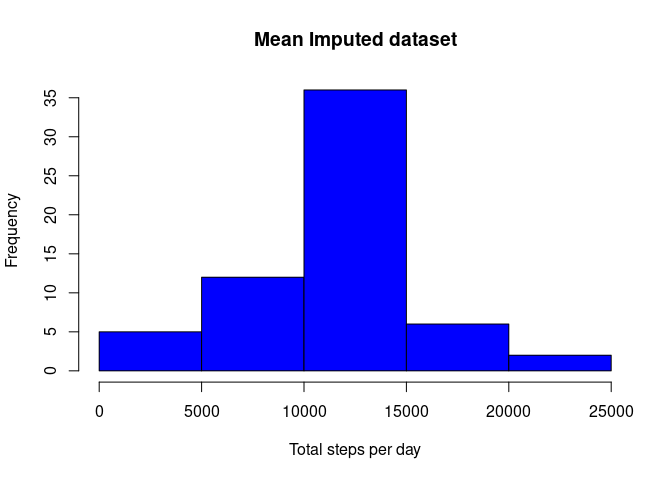

```r
impdata <- aggregate(steps ~ date,imputed_dataset,sum, na.rm = TRUE)
hist(impdata$steps, xlab= "Total steps per day",col='blue',main='Mean Imputed dataset')
```

Mean:

```r
(mean(imputed_dataset[,1]))
```

```
## [1] 37.3826
```

Median:

```r
(median(imputed_dataset[,1]))
```

```
## [1] 0
```

## Are there differences in activity patterns between weekdays and weekends?

```r
imputed_dataset$dateType <-  ifelse(as.POSIXlt(imputed_dataset$date)$wday %in% c(0,6), 'weekend', 'weekday')
head(imputed_dataset)
```

```
##     steps       date interval dateType
## 1 37.3826 2012-10-01        0  weekday
## 2 37.3826 2012-10-01        5  weekday
## 3 37.3826 2012-10-01       10  weekday
## 4 37.3826 2012-10-01       15  weekday
## 5 37.3826 2012-10-01       20  weekday
## 6 37.3826 2012-10-01       25  weekday
```

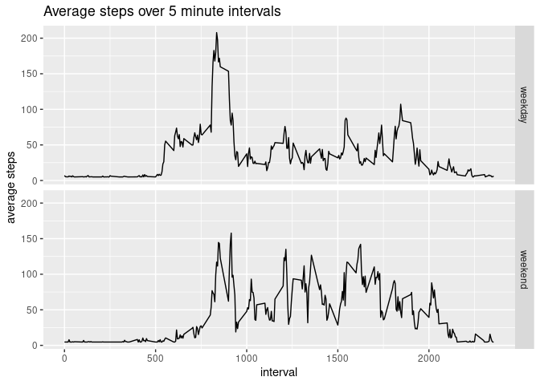

```r
imputed_dataset$daytype <- factor(imputed_dataset$dateType, levels=c("weekday","weekend"))
newintervalmean <- aggregate(x=list(mean=imputed_dataset$steps),
                          by=list(interval=imputed_dataset$interval, dateType=imputed_dataset$dateType),
                          FUN=mean,
                          na.rm=TRUE)
ggplot(newintervalmean, aes(interval,mean))+geom_line()+facet_grid(newintervalmean$dateType~.)+
  labs(y="average steps", title="Average steps over 5 minute intervals")
```